# Class Notes 9-4-24

Sarah Cannon

9/4/2024

```r
#This makes figures smaller when the file is knit, which can help with readability when you have a long document with many figures
knitr::opts_chunk$set(fig.width=4, fig.height=3)
```

## Announcements

Homework 1 Due Tonight at 11:59pm on Gradescope as a PDF. Assign *all* pages to a question! https://help.gradescope.com/article/fnbn2knmq1-how-can-i-submit-my-homework-as-a-pdf

Upcoming office hours:

- Monday 1:15-2:15pm
- Tuesday 10:30-11:30am and 2-3pm
- Wednesday 1:15-2:15pm

Homework Collaboration: If want to be connected with classmates, send me an email; will put students in touch with each other

Template for class notes: On Canvas, Files > Class Materials > 9-4 Class Notes Template

Homework 2 (50 points, half normal length): Due **TUESDAY**, 9/10

Questions about upcoming schedule?

# Scatterplots

## Preclass Video

Make plots by adding visual elements and transformations layer by layer.

```r
library(ggplot2) #Or: library(tidyverse) - ggplot2 is part of tidyverse!
```

Example:

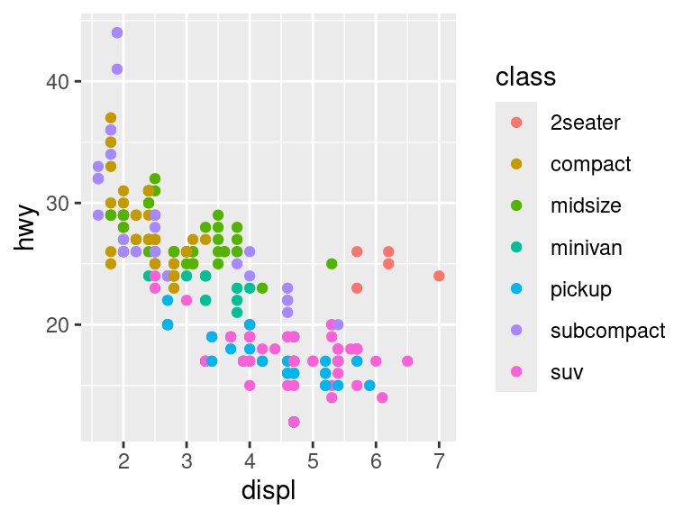

```r
ggplot(data = mpg)  +
  geom_point(mapping = aes(x = displ, y = hwy, color = class))
```

(To split command up onto separate line: Put + at the end of the previous line)

Questions from Pre-class Video?

## Inside/Outside aesthetic

Can change all points to the same color:

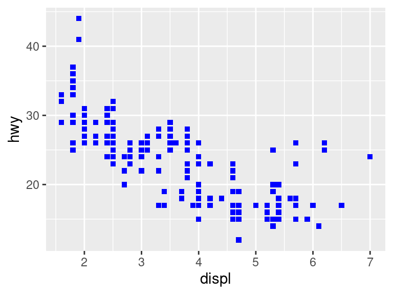

```r
ggplot(data = mpg) +
  geom_point(mapping = aes(x = displ, y = hwy), color = "blue", shape = "square")
```

Inside aes(): when it depends on data values Outside aes(): when it applies to the entire plot/ every data value

This is another example of functions using default values: geom_point() has an argument for color, it’s just set to black unless it’s otherwise specified.

## Adding a Third Variable - Numeric and Categorical

Scatterplots: for showing relationships between two variables (columns)

In general, variables = columns; observations = rows

```r
mpg
```

```
## # A tibble: 234 × 11
##    manufacturer model      displ  year   cyl trans drv     cty   hwy fl    class
##    <chr>        <chr>      <dbl> <int> <int> <chr> <chr> <int> <int> <chr> <chr>
##  1 audi         a4           1.8  1999     4 auto… f        18    29 p     comp…
##  2 audi         a4           1.8  1999     4 manu… f        21    29 p     comp…
##  3 audi         a4           2    2008     4 manu… f        20    31 p     comp…
##  4 audi         a4           2    2008     4 auto… f        21    30 p     comp…
##  5 audi         a4           2.8  1999     6 auto… f        16    26 p     comp…
##  6 audi         a4           2.8  1999     6 manu… f        18    26 p     comp…
##  7 audi         a4           3.1  2008     6 auto… f        18    27 p     comp…
##  8 audi         a4 quattro   1.8  1999     4 manu… 4        18    26 p     comp…
##  9 audi         a4 quattro   1.8  1999     4 auto… 4        16    25 p     comp…
## 10 audi         a4 quattro   2    2008     4 manu… 4        20    28 p     comp…
## # ℹ 224 more rows
```

(later in this course: how to transform data so this is true)

Sometimes, want to incorporate a third (or fourth!) variable into the plot.

Variables come in two types: categorical and numerical

Numerical Variables: values are numbers

Ex. displ

Categorical variables: values come from a list of possibilities

Ex. manufacturer column of mpg, drv column of mpg

To see the different values a categorical variable can take on:

```r
unique(mpg$manufacturer)
```

```
##  [1] "audi"       "chevrolet"  "dodge"      "ford"       "honda"
##  [6] "hyundai"    "jeep"       "land rover" "lincoln"    "mercury"
## [11] "nissan"     "pontiac"    "subaru"     "toyota"     "volkswagen"
```

```r
unique(mpg$drv)
```

```
## [1] "f" "4" "r"
```

```r
unique(mpg$displ)
```

```
##  [1] 1.8 2.0 2.8 3.1 4.2 5.3 5.7 6.0 6.2 7.0 6.5 2.4 3.5 3.6 3.0 3.3 3.8 4.0 3.7
## [20] 3.9 4.7 5.2 5.9 4.6 5.4 5.0 1.6 2.5 2.7 6.1 4.4 5.6 2.2 3.4 1.9
```

Ambiguous cases exist!

For example: year - whether you consider it to be categorical or numeric depends on context

### Option 1: color

Can be used for categorical variables when there aren’t too many categories (every category gets a different color)

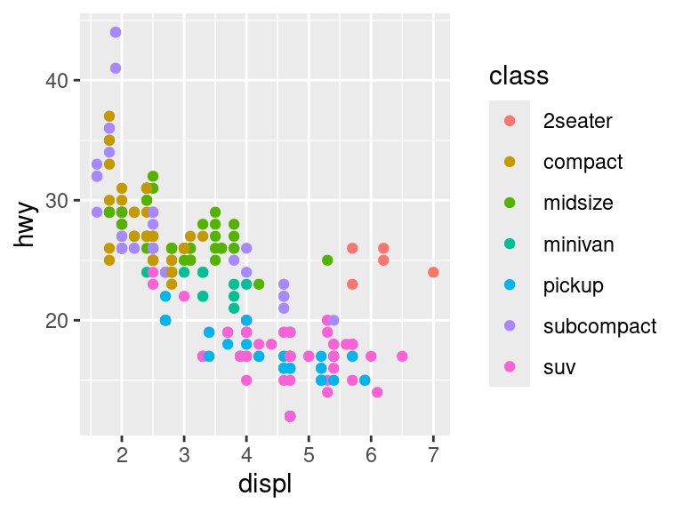

```r
ggplot(data = mpg) +
  geom_point(mapping = aes(x = displ, y = hwy, color = class))
```

(If there were 50 different classes, it might be hard to distinguish them)

Can be used for numeric variables too: get a color gradient

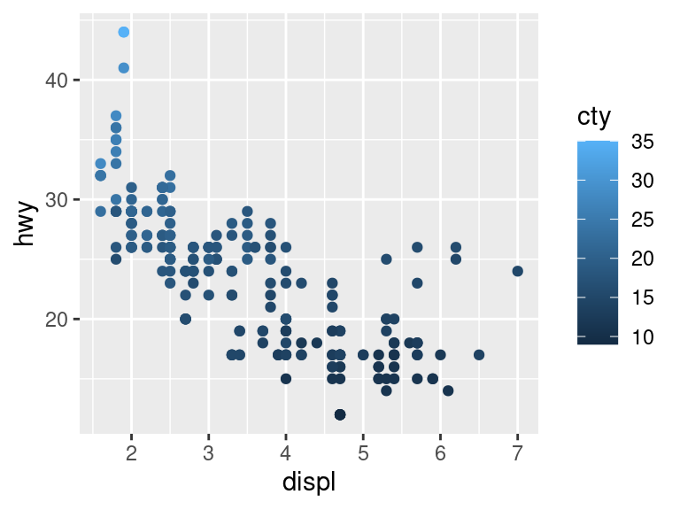

```r
ggplot(data = mpg) +
  geom_point(mapping = aes(x = displ, y = hwy, color = cty))
```

### Option 2: Size

Best when used for numeric variables

(Saw in preclass video: not a great choice for categorical variables like class)

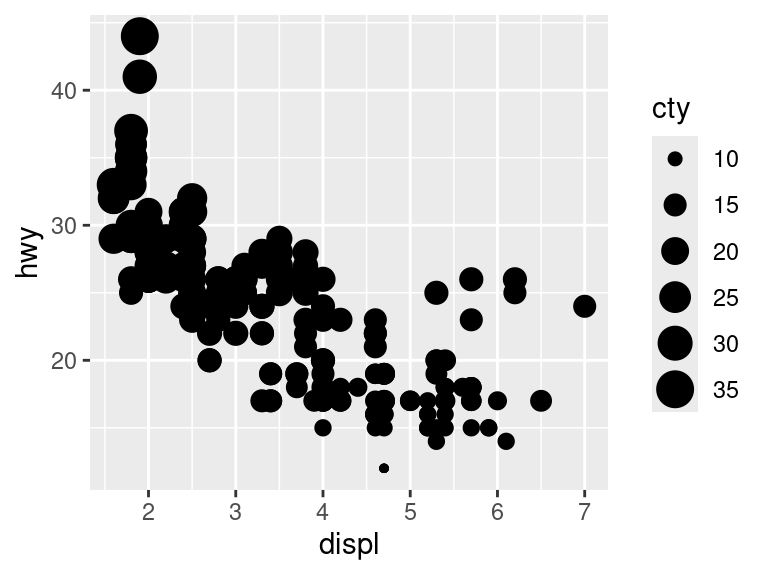

```r
ggplot(data = mpg) +
  geom_point(mapping = aes(x = displ, y = hwy, size = cty))
```

### Option 3: Shape

Can only be used for categorical variables when there’s 6 or fewer categories

```
## Warning: The shape palette can deal with a maximum of 6 discrete values because more
## than 6 becomes difficult to discriminate
## ℹ you have requested 7 values. Consider specifying shapes manually if you need
##   that many have them.
```

```
## Warning: Removed 62 rows containing missing values or values outside the scale range
## (`geom_point()`).
```

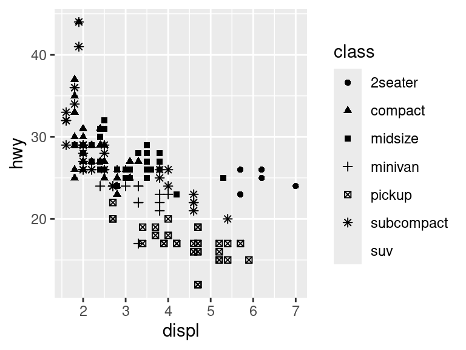

```r
ggplot(data = mpg) +
  geom_point(mapping = aes(x = displ, y = hwy, shape = class))
```

Note: PAY ATTENTION TO WARNINGS!!!! Points for class “suv” are omitted from the plot, there were 62 of them.

There are only 3 value for drv:

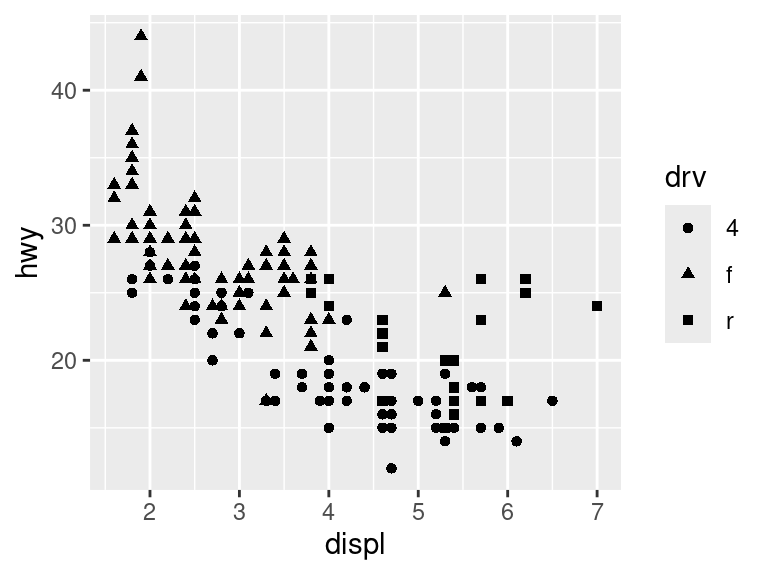

```r
ggplot(data = mpg) +
  geom_point(mapping = aes(x = displ, y = hwy, shape = drv))
```

Note are some points on top of each other! Will learn how to deal with this next.

## Additional geom_point options

How many data points should there be? One for each row!

```r
mpg
```

```
## # A tibble: 234 × 11
##    manufacturer model      displ  year   cyl trans drv     cty   hwy fl    class
##    <chr>        <chr>      <dbl> <int> <int> <chr> <chr> <int> <int> <chr> <chr>
##  1 audi         a4           1.8  1999     4 auto… f        18    29 p     comp…
##  2 audi         a4           1.8  1999     4 manu… f        21    29 p     comp…
##  3 audi         a4           2    2008     4 manu… f        20    31 p     comp…
##  4 audi         a4           2    2008     4 auto… f        21    30 p     comp…
##  5 audi         a4           2.8  1999     6 auto… f        16    26 p     comp…
##  6 audi         a4           2.8  1999     6 manu… f        18    26 p     comp…
##  7 audi         a4           3.1  2008     6 auto… f        18    27 p     comp…
##  8 audi         a4 quattro   1.8  1999     4 manu… 4        18    26 p     comp…
##  9 audi         a4 quattro   1.8  1999     4 auto… 4        16    25 p     comp…
## 10 audi         a4 quattro   2    2008     4 manu… 4        20    28 p     comp…
## # ℹ 224 more rows
```

Can see number of rows at the bottom left of the displayed table. Or, ask for number of rows explicitly!

```r
nrow(mpg)
```

```
## [1] 234
```

When there is rounding, may end up with points on top of each other. A few different ways to see if this is happening.

1. Use position = “jitter”

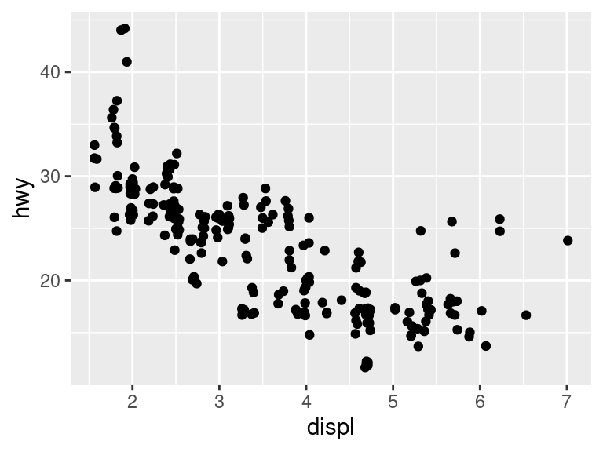

```r
ggplot(data = mpg) + geom_point(mapping = aes(x = displ, y = hwy), position = "jitter")
```

2.Use alpha to make points partially transparent. Value should be between 0 (totally transparent) and 1 (not at all transparent)

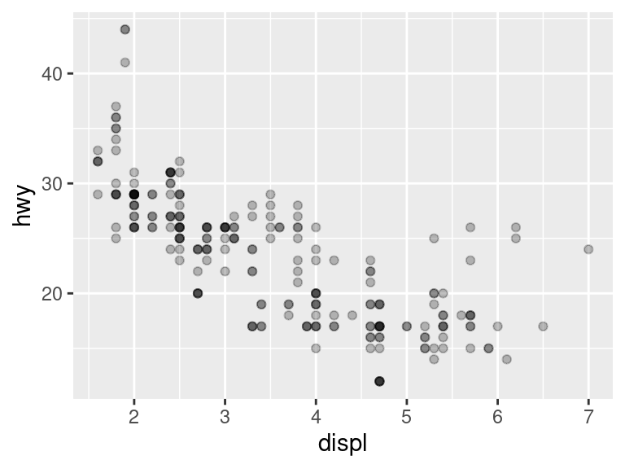

```r
ggplot(data = mpg) +
  geom_point(mapping = aes(x = displ, y = hwy), alpha = 0.25)
```

3. Use geom_count: makes points bigger when there’s more observations there.

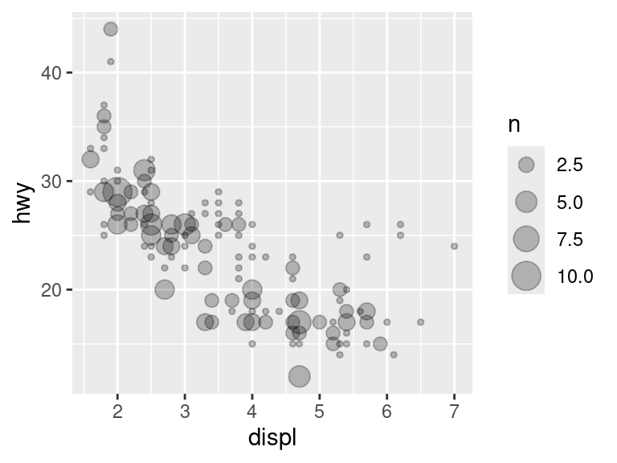

```r
ggplot(data = mpg) + geom_count(mapping = aes(x = displ, y = hwy), alpha = 0.25)
```

Which option you use depends on your data, and which best conveys the information you want to convey.

# Bar Charts for Categorical Variables

Scatterplots need at least two numeric variables

What if you want to begin to understand categorical variables? Use bar charts!

Show how frequently different values (from the list of possibilities) show up in the data set

Q. How frequently do different manufacturers appear in the mpg data set?

Use geom_bar

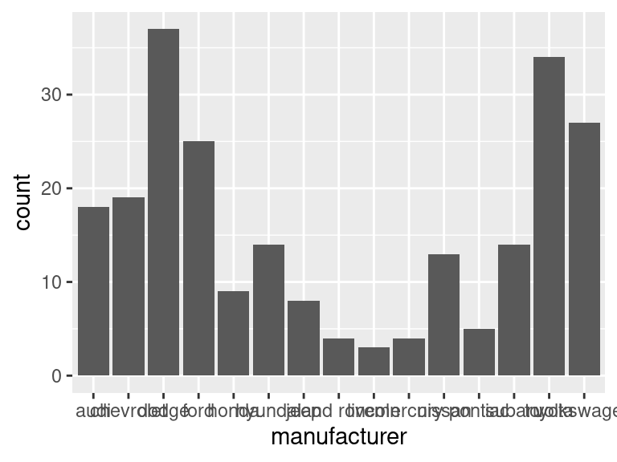

```r
ggplot(data = mpg) + geom_bar(mapping = aes(x = manufacturer))
```

No y aesthetic is needed - only need one variable for a bar chart

Default y value is count

Can sometimes be hard to read x-axis: can flip this plot, make horizontal instead of vertical bars.

Option 1: Set y = manufacturer

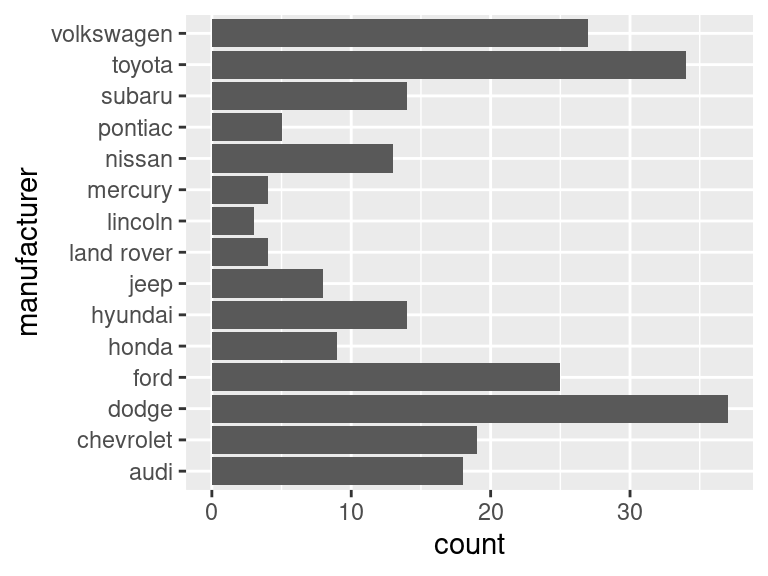

```r
ggplot(data = mpg) +
  geom_bar(mapping = aes(y = manufacturer))
```

(Now the x-axis is count)

Option 2: Add another layer to our plot: a transformation layer

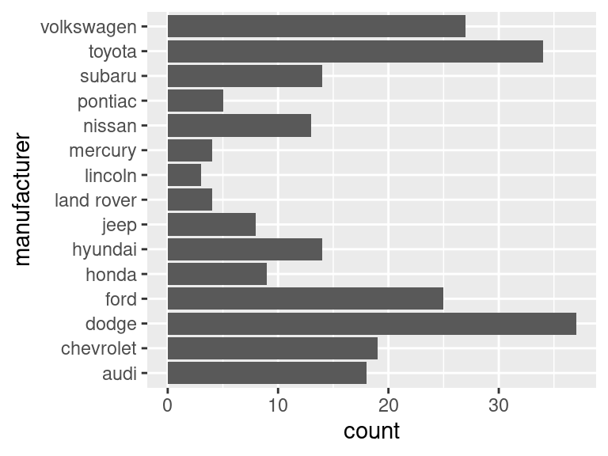

```r
ggplot(data = mpg) +
  geom_bar(mapping = aes(x = manufacturer)) +
  coord_flip()
```

By default, all geom_bars do is count the number of times different values appear.

(will see later on how to do much more with them)

## Composition Chart

Uses color, not separate bars, to look at how many times different categories appear in the data.

Like a bar chart with a single bar: no x-value, but you can color the single bar according to the parts of the data.

We’ll switch to using the diamonds data set

```r
diamonds
```

```
## # A tibble: 53,940 × 10
##    carat cut       color clarity depth table price     x     y     z
##    <dbl> <ord>     <ord> <ord>   <dbl> <dbl> <int> <dbl> <dbl> <dbl>
##  1  0.23 Ideal     E     SI2      61.5    55   326  3.95  3.98  2.43
##  2  0.21 Premium   E     SI1      59.8    61   326  3.89  3.84  2.31
##  3  0.23 Good      E     VS1      56.9    65   327  4.05  4.07  2.31
##  4  0.29 Premium   I     VS2      62.4    58   334  4.2   4.23  2.63
##  5  0.31 Good      J     SI2      63.3    58   335  4.34  4.35  2.75
##  6  0.24 Very Good J     VVS2     62.8    57   336  3.94  3.96  2.48
##  7  0.24 Very Good I     VVS1     62.3    57   336  3.95  3.98  2.47
##  8  0.26 Very Good H     SI1      61.9    55   337  4.07  4.11  2.53
##  9  0.22 Fair      E     VS2      65.1    61   337  3.87  3.78  2.49
## 10  0.23 Very Good H     VS1      59.4    61   338  4     4.05  2.39
## # ℹ 53,930 more rows
```

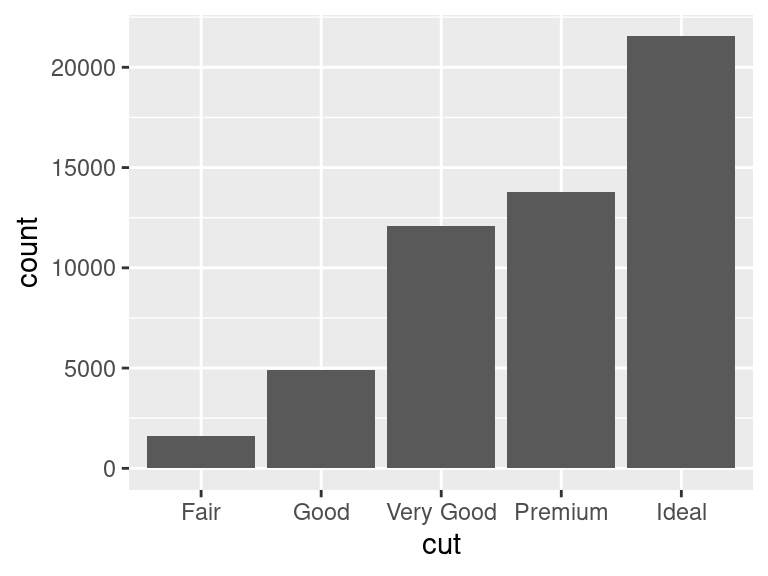

```r
ggplot(data = diamonds) + geom_bar(mapping = aes(x = cut))
```

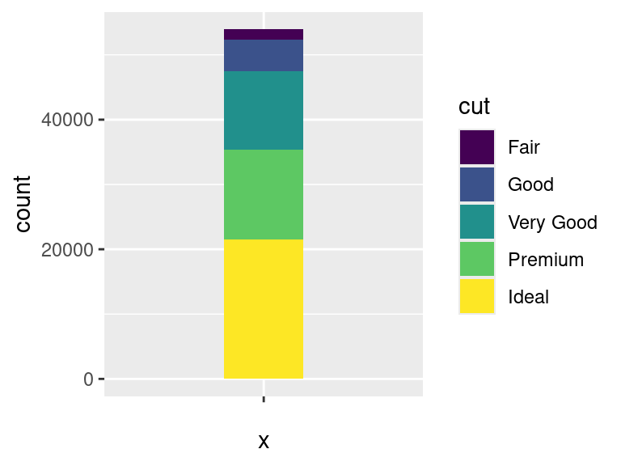

```r
ggplot(data = diamonds) +
  geom_bar(mapping = aes(fill = cut, x = ""), width = 0.3)
```

(width = 0.3 is just to make it look nicer, not required)

Just like with bar charts, by default y is count

Check: are just under 54,000 diamonds in the data, this plot is counting all of them.

Can change y-axis to proportions instead of count: position = “fill”

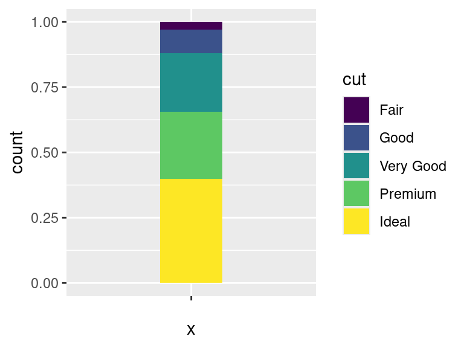

```r
ggplot(data = diamonds) +
  geom_bar(mapping = aes(x = "", fill = cut), position = "fill", width = 0.3)
```

Now y axis goes from 0 to 1: while label still says count, values are proportions/fractions.

Will learn later in class how to change it - YOU SHOULD ALWAYS CHANGE THE Y-AXIS LABEL

## Bar charts with two categorical Variables

What is relationship between cut and clarity for diamonds?

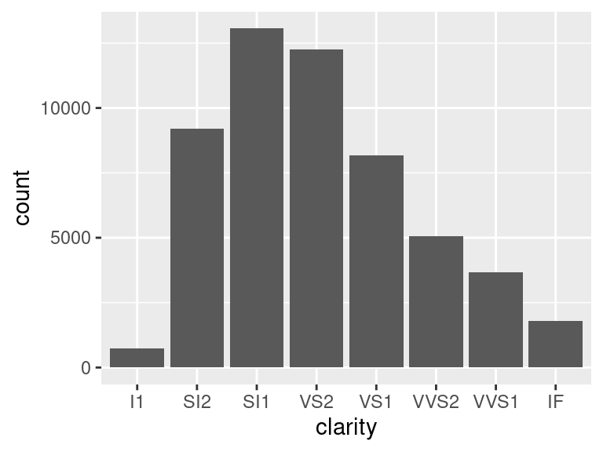

```r
ggplot(data = diamonds) + geom_bar(mapping = aes(x = clarity))
```

What if we want to understand the relationship between cut and clarity? Both are categorical variables.

We can do this! Just make a composition plot for each clarity level, rather than one composition plot for the whole data set.

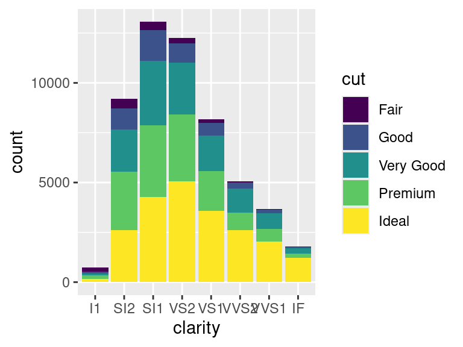

```r
ggplot(data = diamonds) + geom_bar(mapping = aes(x = clarity, fill = cut ))
```

Among ideal diamonds, there are the most diamonds that are clarity VS2

Ideal diamonds seem to the most likely cut for every clarity level except SL2 and maybe L1, too small to tell.

By default, y axis is counting the number of times each of these occurs in the data set.

If want to compare proportions rather than counts: use position = “fill”. This makes all bars the same height.

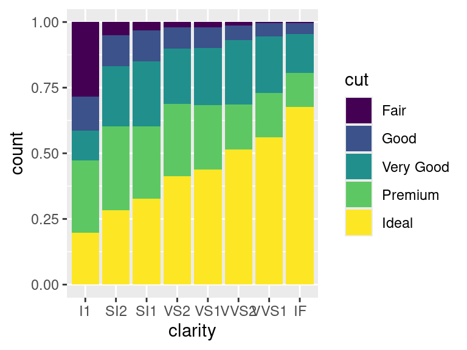

```r
ggplot(data = diamonds) + geom_bar(mapping = aes(x = clarity, fill = cut), position = "fill")
```

Lose: Information about how many diamonds there are of each clarity, which clarity levels appear more frequently, etc.

Gain: Information about how the proportions of different cuts within each clarity level compare.

(Note: Should always change y-axis to say proportion, rather than count)

Takeaways: Diamonds of IF clarity are most likely to be ideal cut. As clarity increases, so does likelihood of being ideal cut.

By swapping x and fill, can learn different things about your data:

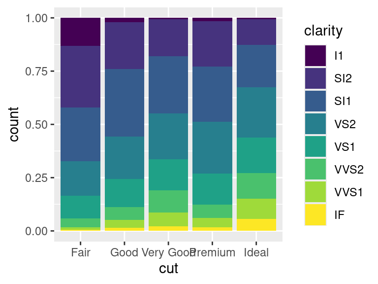

```r
ggplot(data = diamonds) + geom_bar(mapping = aes(fill = clarity, x = cut), position = "fill")
```

What if we want to turn each column of colors back into a bar chart? Use position = “dodge”

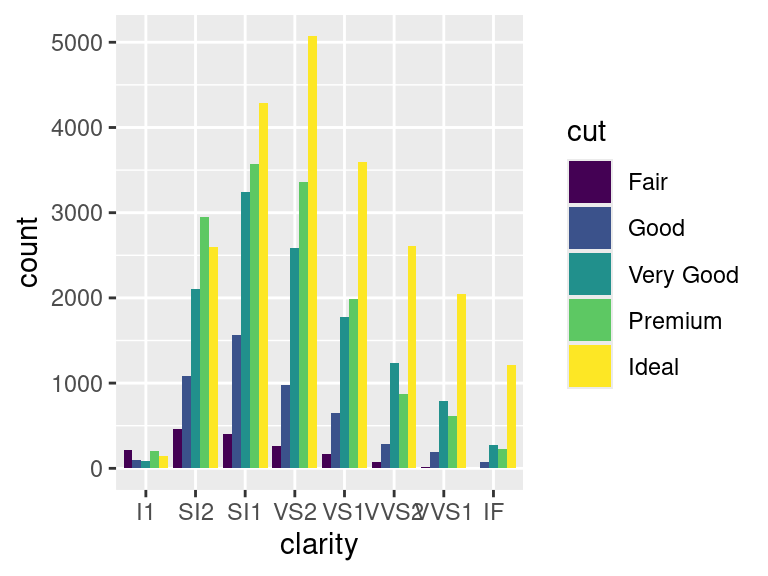

```r
ggplot(data = diamonds) +
  geom_bar(mapping = aes(x = clarity, fill = cut), position = "dodge" )
```

Which options you use depends on your questions/what you’re trying to learn from your data.

Options:

- position: default, “fill”, “dodge”
- which variable is x, which variable is fill

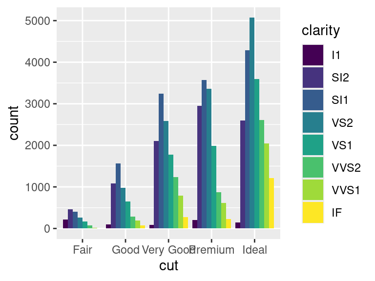

```r
ggplot(data = diamonds) +
  geom_bar(mapping = aes(fill = clarity, x = cut), position = "dodge" )
```

(same bars, just grouped/colored differently)

# Additional Options: Titles, Labels, Limits

You can change your plot by adding even more layers!

## Titles

To add a title: do + ggtile(“Your TItle Here”)

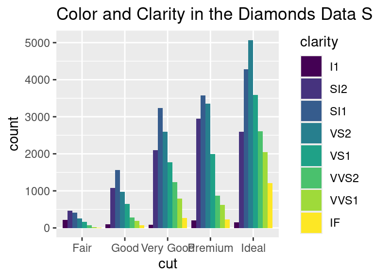

```r
ggplot(data = diamonds) +
  geom_bar(mapping = aes(x = cut, fill = clarity), position = "dodge") +
  ggtitle("Color and Clarity in the Diamonds Data Set")
```

## Axis Labels

To change an axis label: use + labs(x = “New x label”, y = “New y label”)

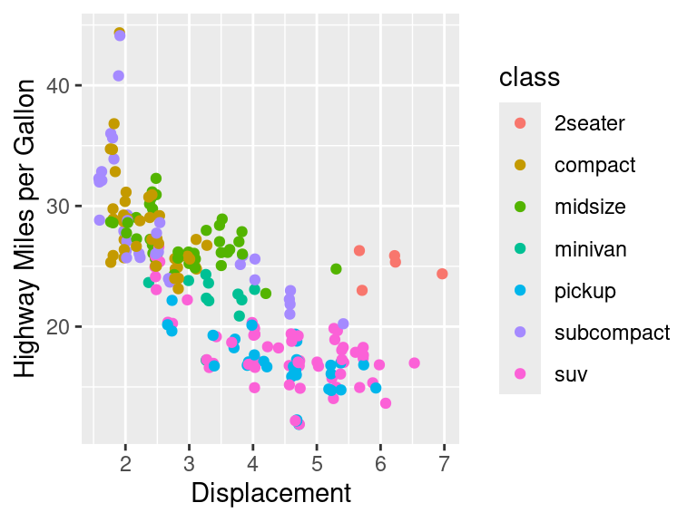

```r
ggplot(data = mpg) +
  geom_point(mapping = aes(x = displ, y = hwy, color = class), position = "jitter") +
  labs(x = "Displacement", y = "Highway Miles per Gallon")
```

When using proportion = “fill” in bar charts - always change y label from “count” to something that’s correct, like “Proportion” or “Fraction”

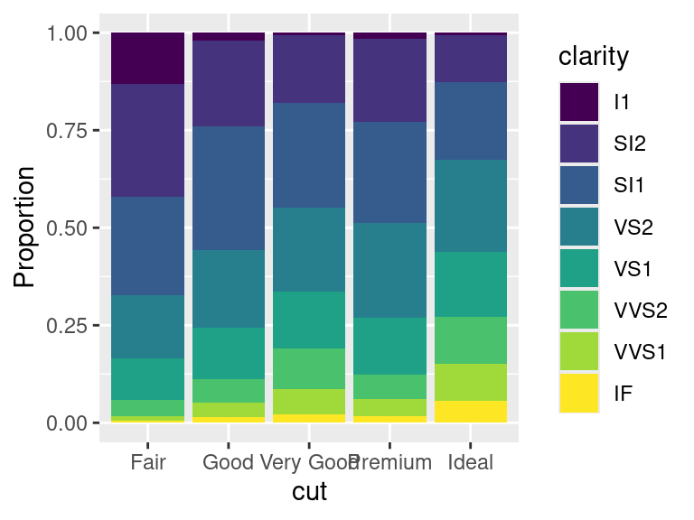

```r
ggplot(data = diamonds) +
  geom_bar(mapping = aes(fill = clarity, x = cut), position = "fill") +
  labs(y = "Proportion")
```

Want plots to be clear, readable, and convey useful information!

Can also use labs() for: title, subtitle, and much more!

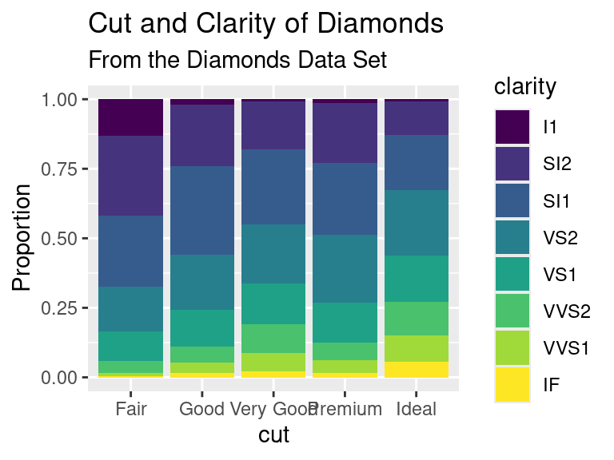

```r
ggplot(data = diamonds) +
  geom_bar(mapping = aes(fill = clarity, x = cut), position = "fill") +
  labs(y = "Proportion", title = "Cut and Clarity of Diamonds", subtitle = "From the Diamonds Data Set")
```

## Axis limits

Maybe you only want to look at a subset of the data;use xlim() or ylim()

```
## Warning: Removed 197 rows containing missing values or values outside the scale range
## (`geom_point()`).
```

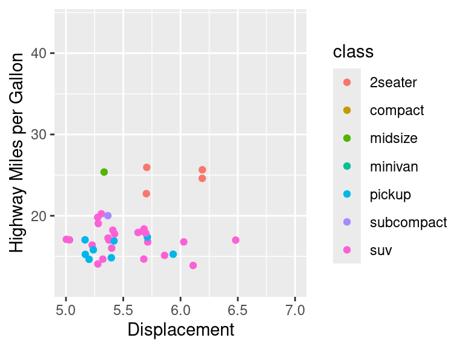

```r
ggplot(data = mpg) +
  geom_point(mapping = aes(x = displ, y = hwy, color = class), position = "jitter") +
  labs(x = "Displacement", y = "Highway Miles per Gallon") +
  xlim(5,7)
```

Note: Pay attention to warnings, and how many points have been omitted by adding these limits!

# Summary

Can make ggplots by adding on various layers - some layers involve data, some layers involve transformations, some layers involve other edits/additions

geom_point: make a scatterplot - Use for two numeric variables, can add in additional variables via color, size, shape - Other options include position, alpha, using geom_count() instead

geom_bar: make a bar chart that counts how many times different values appear in the data - Can use for 1 or 2 categorical variables - options include position, which variable is x, which variable is fill

Additional layers:

- coord_flip(): Flips x and y axis
- ggtitle(): adds a title
- labs(): changes axis labels, add subtitle/title
- xlim(), ylim(): changes bounds on axes

# Activity

On Canvas, Files > Class Material > 9-4 Activity

If finish all regular questions, move on to bonus question (plotting wildfires).

If finish bonus question, can leave: check in with Prof. Cannon before leaving

Feel free to talk to/work with others around you.